# Microbial Allee Effect

RajReni Kaul

12/12/2014

# Methods

## Experiment

*Correction* 2/10/15 Realized 96 well plates also had Stabb marine media, not LBS! Now the difference between ‘good’ and ‘poor’ is glycerol concentration, 40mM vs 20mM glycerol.

## Model Fitting

The presence of Allee effects was tested based on Dennis, B. 2002. Allee effects in stochastic populations. Oikos 96: 389-401. Demographic stochasticity, which can produce Allee-like behavior, can be differentiated from true Allee dynamics when examining the probability of extinction/establishment as a function of population size. Populations subject to Allee effects have very different probabilities of extinction above and below the lower critial size. This dramatic change in rates results in an inflection point at the critical population size. Populations subject to demographic noise will lack this inflection point in the probability of extinction. The presence of an inflection point can then surve as a test for the presence of an Allee effect. We used the Weibull function that will be sigmoidal (ie. have an inflection point) when $k>1$. $\begin{aligned} y &= 1-e^{(\frac{-x}{\lambda})^{k}} && \text{Expression for Weibull} \\ \ddot{x} &= \lambda \sqrt[k]{\frac{k-1}{k}} && \text{Inflection Point of Sigmoid} \end{aligned}$

In this case, y is probability of establishment, and x is the initial population size.

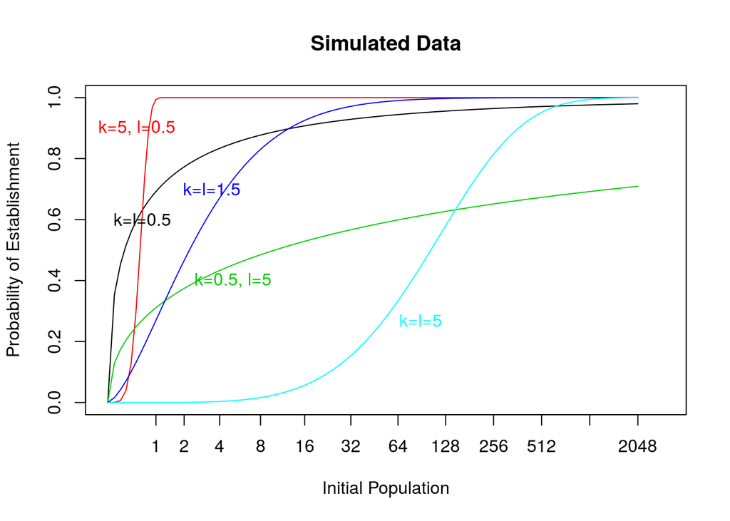

The inflection point is bounded between (0, $\lambda$), therefor the threshold to detect an Allee effect should include $k > 1$ and $\lambda > 1$ cell/mL. Since different volume was used for the good environment, the $\lambda$ threshold differs, 0.2 for the good environment and 0.075 for the poor environment. For ease of comparison, all treatments were converted to the same scale of cells/mL before parameter estimation. Population size was log transformed for model fitting.

# Data Prep

Need to currate data files: -type -plate

## Good Environment

The data for the good environment was collected at a different time/trials. Three trials of 96well plates were run for the good environment. The following code chunk starts with the OD by time then: 1. Combines all 3 trials 2. Adds treatment information for each well 3. Determines the time it took each well to reach the minimum detection limit 4. Determine the max value or population size for each well 5. Key populations as established/not based on max value 6. Calculate summary stats for the populations that established

The output of this process is saved in ‘demo.sum’. The populations were grouped by treatment to calculate summary statistics, this is saved in ‘demo.stat’.

```r
######################
#Reshape data files##
#####################

#Demographic data is split across 3 96 well plates
#Demographic trial data
read.csv('data/demo_pl1.csv',header=T)->d1
pr.reformat('data/demo_pl2.txt')->d2
pr.reformat('data/demo_pl3.txt')-> d3

###Need to remove uness columns
#add sampling info to data not recorded by plate reader
plate<-c(1)
cbind(plate,d1)->d1
plate<-c(2)
cbind(plate,d2)->d2
plate<-c(3)
cbind(plate, d3)->d3

rbind(d1[,-c(3,4,5)],d2[,-c(3,4)],d3[,-c(3,4)])->data
#reshape data
#md<-melt(d, id=c("plate","Measurment"), variable.name="Well", value.name="Growth")

#read in plate maps
read.csv('data/demoplatemap.csv', header=T)-> p3

#calculate summary stat

ttothreshold(data=data,cat.type=data$plate,n.cat=3,thres=0.25, convert=(5/60))->demo.sum
#add experimental treatment info to each population
inner_join(demo.sum,p3, by='Well')->demo.sum
#prep data by grouping in experimental treatments of "Initial" population size
demo.group<- group_by(demo.sum, Initial)

demo.stat<-summarise(demo.group, p.N=length(persist), p.ave=mean(persist), p.sd=sd(persist), est.N=length.na(hour), est.ave=mean.na(hour), est.sd=sd.na(hour), y.N=length(new.yield[which(new.yield>0)]), y.ave=mean(new.yield[which(new.yield>0)]), y.sd=sd(new.yield[which(new.yield>0)]))

demo.stat[which(demo.stat$Initial>0),]->demo.stat #remove negative control wells
(demo.stat$Initial/200)*1000->adj.initial #density of initial population (cells/mL)
cbind(adj.initial, demo.stat)->demo.stat

#demo.sum has info by well
#demo.stat has summary statistics by treatment
```

## Poor and Predation Environment: Trial 15

The data for the poor and predation environment is from Trial 15, which used a 384 well plate. The plate was read for OD and fluorescence. Fluorescence was read at 3 sensitivity levels. All levels lead to the same patterns. The following chunk reads in the combined OD and RFU by time then:

1. Assigns read type 1 through 4 (type 1: OD, type 2-4: fluorsecence at different sensitivity)
2. Adds treatment information for each well
3. Determines the time it took each well to reach the minimum detection limit
4. Determine the max value or population size for each well
5. Key populations as established/not based on max value
6. Calculate summary stats for the populations that established

The out put of this process is saved as ‘final.sum’. The populations were grouped by treatment to calculate summary statistic, this is saved in ‘stat’.

```r
#Trial 15 full data
pr.reformat('data/11-18-13-T15_ALL.txt')->T15raw #this is a big file, takes a few seconds to load
T15raw[,-c(1:3)]->T15 #remove non-informative col
Type=c(1:4) #as in read type
Time<-sort(rep(c(1:381),4)) #time in read number

cbind(Time,Type,T15)->T15
#reshape data
mT15<-melt(T15, id=c("Type", "Time"), variable.name="Well", value.name="Growth")

#read in plate maps
read.csv('data/platemap384.csv', header=T)-> p1

#Two data types
#T15
#mT15
#Only interested in OD data, so pull out type 1 from T15
T15[which(T15$Type==1),]->tempdata
ttothreshold(data=tempdata,cat.type=tempdata$Type,n.cat=1,thres=0.25, convert=.25)->sum
#add experimental treatment info to well
inner_join(sum,p1, by='Well')->final.sum
#group by experimental treatments
grouped<- group_by(final.sum,  Initial, Cafeteria)

stat<-summarise(grouped, p.N=length(persist), p.ave=mean(persist), p.sd=sd(persist), p.total=sum(persist), y.N=length(new.yield[which(new.yield>0)]), y.ave=mean(new.yield[which(new.yield>0)]), y.sd=sd(new.yield[which(new.yield>0)]), est.N=length.na(est), est.ave=mean.na(est), est.sd=sd.na(est))

stat[order(stat$Cafeteria),]->stat
as.data.frame(stat)->stat

stat[which(stat$Initial>0),]->stat #remove negative control wells
(stat$Initial/75)*1000->adj.initial #density of initial population (cells/mL)
cbind(adj.initial, stat)->stat


#final.sum has info by well
#stat has summary statistics by treatment
```

# Results

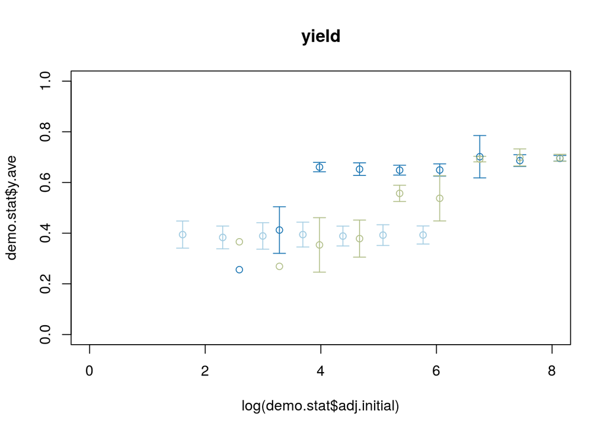

```r
plotCI(y=demo.stat$y.ave, x=log(demo.stat$adj.initial), uiw=demo.stat$y.sd, main='yield', ylim=c(0,1), xlim=c(0,8), gap=0, col="#a6cee3" )
plotCI(y=stat$y.ave, x=log(stat$adj.initial), uiw=stat$y.sd, add=TRUE, col=ifelse(stat$Cafeteria==0,'#1f78b4','#b2bf8a'), gap=0)
```

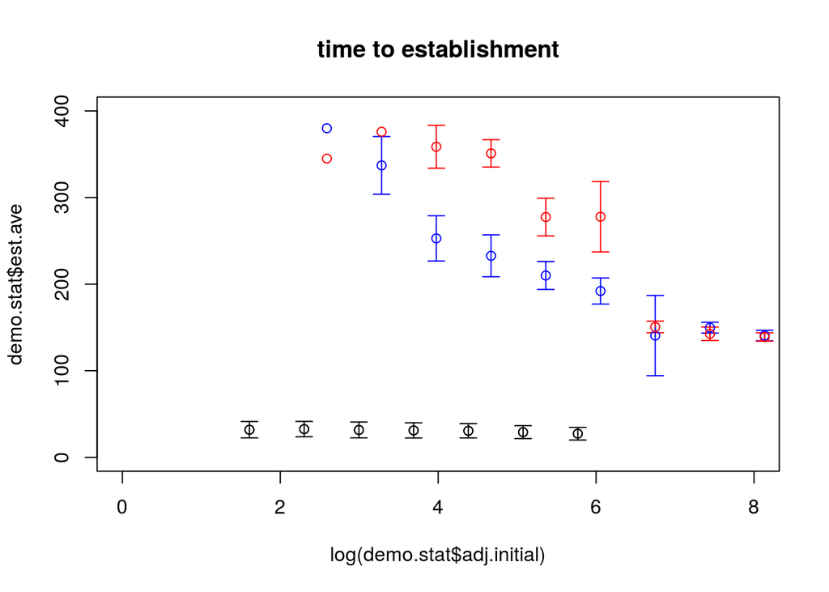

```r
plotCI(y=demo.stat$est.ave, x=log(demo.stat$adj.initial), uiw=demo.stat$est.sd, main='time to establishment', xlim=c(0,8), gap=0, ylim=c(0,400))
plotCI(y=stat$est.ave, x=log(stat$adj.initial), uiw=stat$est.sd, add=TRUE, col=ifelse(stat$Cafeteria==0,'blue','red'), gap=0)
```

```r
demo.stat
```

```
##   adj.initial Initial p.N     p.ave      p.sd est.N  est.ave   est.sd y.N
## 1           5       1  36 0.5277778 0.5063094    19 31.90368 9.480410  19
## 2          10       2  36 0.7222222 0.4542568    26 32.63500 8.852966  26
## 3          20       4  36 0.9722222 0.1666667    35 31.62400 9.128937  35
## 4          40       8  36 1.0000000 0.0000000    36 31.13139 8.794210  36
## 5          80      16  36 1.0000000 0.0000000    36 30.65806 8.285255  36
## 6         160      32  36 1.0000000 0.0000000    36 29.10639 7.470393  36
## 7         320      64  36 1.0000000 0.0000000    36 27.34000 7.313980  36
##       y.ave       y.sd
## 1 0.3943684 0.05347295
## 2 0.3831923 0.04486158
## 3 0.3890286 0.05228513
## 4 0.3944167 0.04899876
## 5 0.3886111 0.03919787
## 6 0.3922500 0.04090922
## 7 0.3928056 0.03573459
```

```r
stat
```

```
##    adj.initial Initial Cafeteria p.N      p.ave      p.sd p.total y.N
## 2     13.33333       1         0  12 0.08333333 0.2886751       1   1
## 3     26.66667       2         0  12 0.75000000 0.4522670       9   9
## 4     53.33333       4         0  12 1.00000000 0.0000000      12  12
## 5    106.66667       8         0  12 1.00000000 0.0000000      12  12
## 6    213.33333      16         0  12 1.00000000 0.0000000      12  12
## 7    426.66667      32         0  12 1.00000000 0.0000000      12  12
## 8    853.33333      64         0  12 1.00000000 0.0000000      12  12
## 9   1706.66667     128         0  12 1.00000000 0.0000000      12  12
## 10  3413.33333     256         0  12 1.00000000 0.0000000      12  12
## 11  6826.66667     512         0  12 1.00000000 0.0000000      12  12
## 12 13653.33333    1024         0  12 1.00000000 0.0000000      12  12
## 13 27306.66667    2048         0  12 1.00000000 0.0000000      12  12
## 15    13.33333       1        10  12 0.08333333 0.2886751       1   1
## 16    26.66667       2        10  12 0.08333333 0.2886751       1   1
```

[output cut: 35 more lines]

An Allee effect was detected in ALL treatments. The strength of the Allee effect, as measured by the inflection point or $\lambda$, increased with decreasing environmental quality.

```
##
## Call:
## mle2(minuslogl = LL1, start = initial, method = "SANN", data = data,
##     trace = TRUE)
##
## Coefficients:
##      lam        k
## 1.916673 2.567697
##
## Log-likelihood: -51.85
```

```
##
## Call:
## mle2(minuslogl = LL1, start = initial, method = "SANN", data = data,
##     trace = TRUE)
##
## Coefficients:
##       lam         k
##  3.194334 11.633081
##
## Log-likelihood: -10.19
```

```
##
## Call:
## mle2(minuslogl = LL1, start = initial, method = "SANN", data = data,
##     trace = TRUE)
##
## Coefficients:
##      lam        k
## 4.637244 5.824943
##
## Log-likelihood: -27.74
```

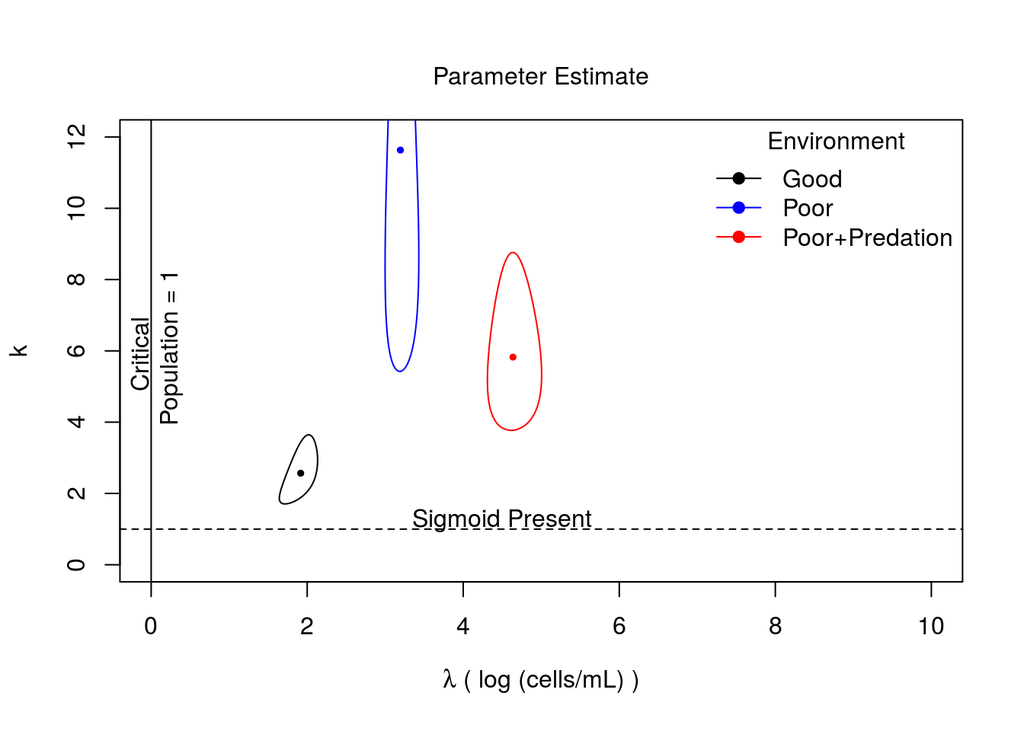

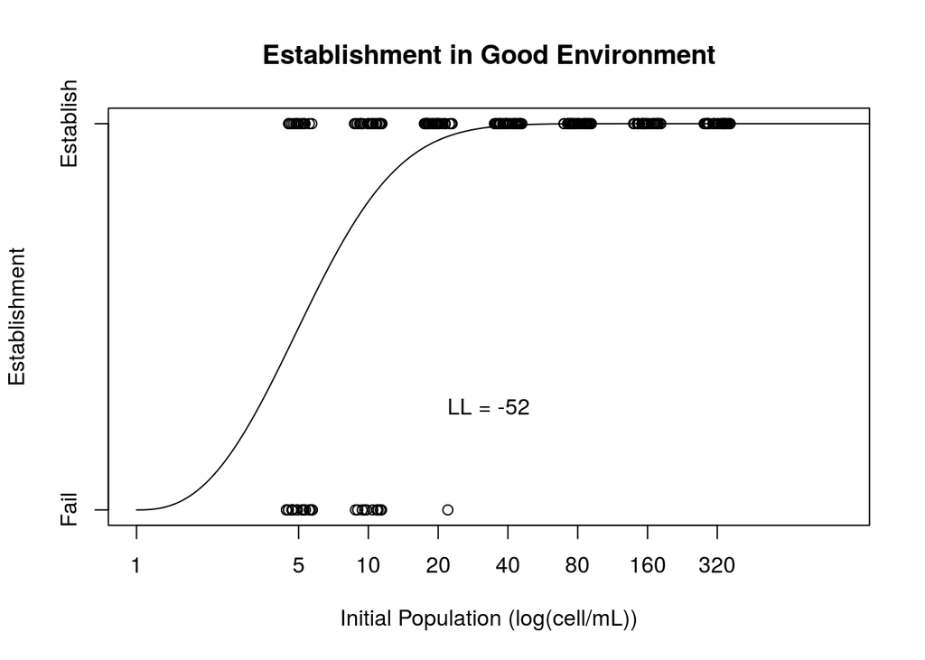

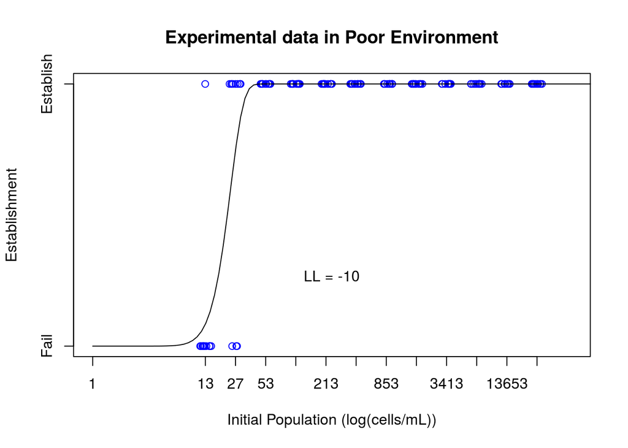

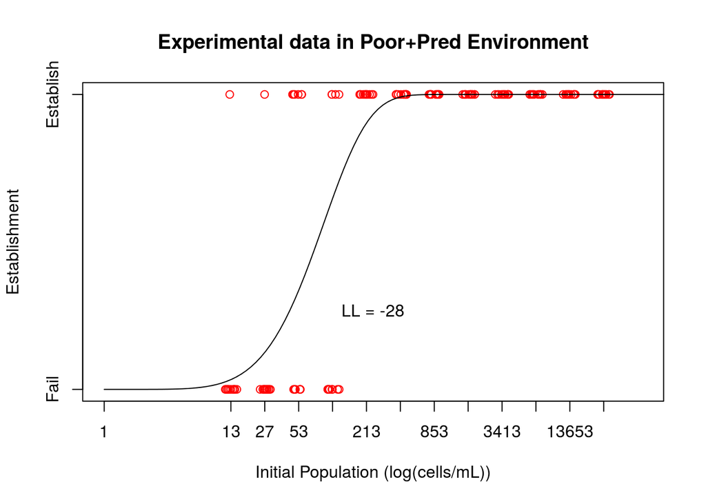

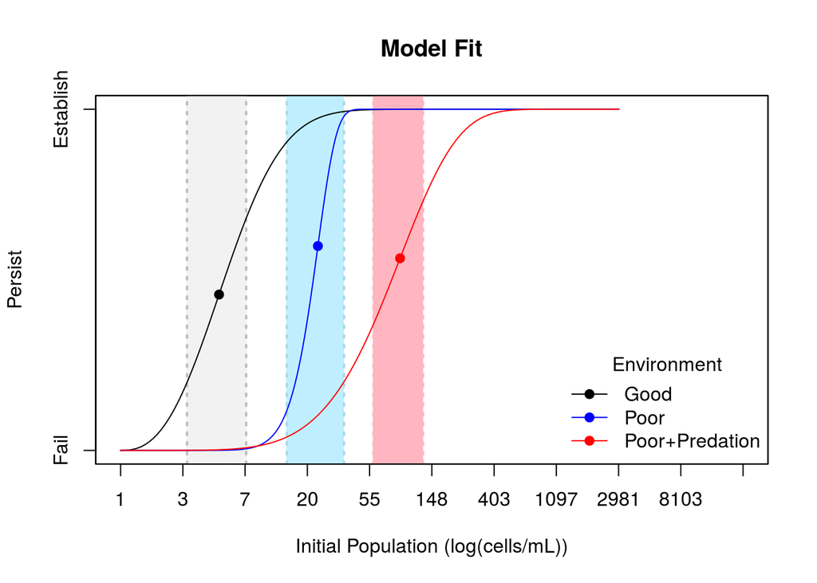